# STRINGS

> String manipulation is arguably one of the most common activities in computer programming.

This is especially true in Web systems, where Java is a major player. In this chapter, we’ll look more deeply at what may be the most heavily used class in the language, String, along with some of its associated classes and utilities.

Conceptually, **Strings** are sequences of Unicode characters. For example string "Java\u2122" consists of five unicode characters "J", "a", "v", "a", "<sup>TM</sup>". Java doesn't have a built-in string type. Instead, the standard Java library has a class **String**. Each quoted string is an instance of class **String**.

```java
String e = ""; // an empty String
String greeting = "Hello";
greeting.charAt(0);
```

```
H
```

## Substrings

There is a possibility to extract a substring from the bigger string. You should use `substring()` method of **String** class. For example,

```java
String greeting = "Hello World";
String s = greeting.substring(0, 5);
System.out.println(s);
System.out.println(greeting);
```

```
Hello
Hello World
```

## Immutable Strings

Objects of the **String** class are immutable. If you examine the JDK documentation for the **String** class, you’ll see that every method in the class that appears to modify a **String** actually creates and returns a brand new **String** object containing the modification. The original String is left untouched.

```java
public static String upcase(String s) {
    return s.toUpperCase();
}

String q = "JavaLang";
System.out.println(q);
String qq = upcase(q);
System.out.println(qq);
System.out.println(q);
```

```
JavaLang
JAVALANG
JavaLang
```

The **String** class gives no methods that let you change a character in a string. If you want to turn a string "Hello" to a string "Help!", you cannot directly change the last positions of a "Hello" string. To do such a thing you need to use create a new string. For example:

```java
String greeting = "Hello";
String help = greeting.substring(0, 3) + "p!";
System.out.println(help);
```

```
Help!
```

## String Pool

As the name suggests, String Pool in java is a pool of Strings stored in Java Heap Memory. Here is a diagram that clearly explains how String Pool is maintained in java heap space and what happens when we use different ways to create Strings.

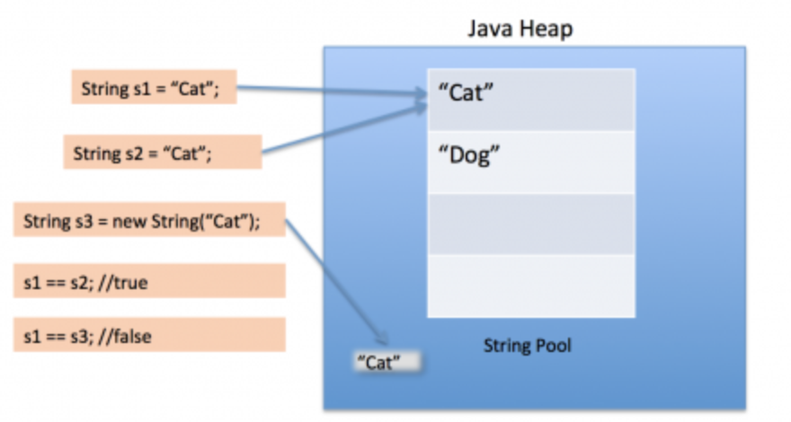

String Pool is possible only because String is immutable in Java and its implementation of String interning concept.

```java
String s1 = "Abc";
String s2 = "Abc";
s2 = "Bcd";
s1 = s2;
String s3 = new String("Abc");
s1.equals(s3);
System.out.println(s1);
System.out.println(s2);
```

[output not shown]

## Concatenation and StringBuilder

Java, like most others programming languages, allows you to use `+` to join (concatenate) to strings.

```java
String hello = "Hello";
String world = "World";
String message = hello + " " + world;
System.out.println(message);
```

```
Hello World
```

This feature is commonly used in the output statements. For example:

```
    int age = 25;
    System.out.println("The person's age is " + a);
```

```java
int a = 5;
int b = 10;
System.out.println("result = " + (a + b));
```

```
result = 15
```

If you need to put multiple strings together, separated by a delimiter, use the static `join` method:

```java
String all = String.join(" / ", "S", "M", "L", "XL");
System.out.println(all);
```

```
S / M / L / XL
```

Since **String** objects are immutable, you can alias to a particular **String** as many times as you want. Because a **String** is read-only, there’s no possibility that one reference will change something that affect the other references. Immutability can have efficiency issues. A case in point is the operator `+` that is overloaded for **String** objects. Overloading means an operation has extra meaning when used with a particular class. (The + and += for String are the only operators overloaded in Java, and Java does not allow the programmer to overload any others.) The `+` operator concatenates **String** as:

```java
String fruit = "Apple";
String thing = "Pen";
String result = thing + fruit + 100500;
System.out.println(result);
```

```
PenApple100500
```

Imagine how this *might work*. The **String** from variable `thing` could have a method **append()** that creates a new **String** object containing “Pen” concatenated with the contents of `fruit`. The new **String** object would then create another new **String** that added “100500” and so on. This would certainly work, but it requires the creation of many **String** objects just to put together this new **String**, then you have a bunch of intermediate **String** objects that must be garbage collected. But things no so bad because under the hood in the byte code you can find using of the **StringBuilder**. Here’s an example that produces a **String** result in two ways: using **String** s, and by hand-coding with **StringBuilder**:

```java
public class DemoStringConcatenation {

    public String implicit(String[] fields) {
        String result = "";
        for (String s : fields) {
            result += s;
        }
        return result;
    }

    public String explicit(String[] fields) {
        StringBuilder result = new StringBuilder();
        for (String s : fields) {
            result.append(s);
        }
        return result.toString();
    }
}
```

The drawback of the first method that in the byte code in the loop **StringBuilder** object will be created for each iteration. In the second method we create **StringBuilder** explicitly. So, no penalties for our memory and performance. As a conslusion: prefer **StringBuilder** rather than **+**. With **StringBuilder**, **String** operations should be faster.

## Testing Strings for Equality

To test whether two strings are equal, use the `equals()` method. The expression `x.equals(y)` returns true if the strings **x** and **y** are equal, false otherwise. Note, that x and y can be string literals or variables. For example:

```java
String greeting = "Hello";
"Hello".equals(greeting);
```

```
true
```

```java
"Hello" == "Hello"
```

```
true
```

To test where two string are equal except for the lower/uppercase distinction, use the `equalsIgnoreCase()` method

```java
"Hello".equalsIgnoreCase("hello");
```

```
true
```

**Do not user the == operator to test whether two strings are equal.** It only determines if two strins are stored in the same location in the memory. It is entirely possible to store same strings in different locations in the memory.

```java
String s1 = "Ho-ho-ho";
if (s1.equals("Ho-ho-ho")) {
    System.out.println("Winter");
} else {
    System.out.println("Summer");
}
```

```
Winter
```

Everything seems to be OK. But here is an another case:

```java
if (s1.substring(0, 2) == "Ho") {
    System.out.println("OK :)");
} else {
    System.out.println("NOT OK :(");
    System.out.println("s1.substring(0, 2) = " + s1.substring(0, 2));
}
```

```
NOT OK :(
s1.substring(0, 2) = Ho
```

Only string literals are shared. But strings, that are results of operations like `substring` or `+` are not. Therefore, never use == to compare strings.

## Empty and Null Strings

The empty string "" is a string of the length 0. You can test whether the string is empty by calling `if (str.length() == 0)` or `if (str.equals(""))`.However a String variable can also have a special value `null`. To test whether string is null use:

```java
String emptyString = "";
String str = null;
if (str == null) {
    System.out.println("String is null");
}
```

```
String is null
```

```java
String s = null;
// code
// request to server
// s = responseFromServer;
if (s == null) {
   System.out.println("Sorry, string is null");
} else {
    s.equals("200");
}
```

```
Sorry, string is null
```

## String API

Here are most of the methods available for String objects.

### length()

To get number of characters in a string you can use method **length()**

```java
String myString = "Abra Kadabra";
System.out.println(myString.length());
```

```
12
```

```java
MyString str = new MyString("Abra Kadabra");
System.out.println(str.length());
```

```
12
```

### charAt(int index)

```java
String hello = "hello!";
System.out.println(hello.charAt(5));
System.out.println(hello.charAt(6));
```

```
!
```

```
---------------------------------------------------------------------------
java.lang.StringIndexOutOfBoundsException: String index out of range: 6
	at java.base/java.lang.StringLatin1.charAt(StringLatin1.java:47)
	at java.base/java.lang.String.charAt(String.java:693)
	at .(#51:1)
```

### getChars(int srcBegin, int srcEnd, char[] dest, int destBegin)

Copies characters from this string into the destination character array.

```java
String address = "https://www.google.com";
char[] destination = new char[address.length()];
address.getChars(8, 22, destination, 0); // 22, because length of string is 21 and the last character is not included
System.out.println(destination);
```

```
www.google.com
```

### toCharArray()

Produces a char[] containing the characters in the String.

```java
String country = "Ukraine";
char[] result = country.toCharArray();
for (char c : result) {
    System.out.println(c);
}
```

```
U
k
r
a
i
n
e
```

### equals(String s)

An equality check on the contents of two strings. Result is true if the contents are equal.

```java
String s1 = "aBc";
String s2 = "aBc";
System.out.println(s1.equals(s2));
```

```
true
```

### equalsIgnoreCase(String s)

An equality check on the contents of the two strings ignoring case. Result is true if the contents are equal.

```java
String s1 = "aBc";
String s2 = "ABC";
System.out.println(s1.equals(s2));
System.out.println(s1.equalsIgnoreCase(s2));
```

```
false
true
```

### compareTo(String anotherString)

### compareToIgnoreCase(String anotherCase)

Result is negative, zero, or positive depending on the lexicographical ordering of the String and the argument. Uppercase and lowercase are not equal!

```java
String a = "ABC";
String b = "abc";
String c = "ABB";
String d = "ABC";
System.out.println(a.compareTo(b));
System.out.println(b.compareTo(a));
System.out.println(a.compareTo(c));
System.out.println(c.compareTo(a));
System.out.println(a.compareTo(d));
```

```
-32
32
1
-1
0
```

**compareTo** returns the difference of the two characters values at the position k in two strings -- that is, the value:

*this.charAt(k) - anotherString.charAt(k)*

```java
String a = "ABC";
String b = "abc";
String c = "ABA";
String d = "CCC";
System.out.println(a.compareToIgnoreCase(b));
System.out.println(b.compareToIgnoreCase(a));
System.out.println(a.compareToIgnoreCase(c));
System.out.println(a.compareToIgnoreCase(d));
```

```
0
0
2
-2
```

### сontains(CharSequence c)

Result is true if the argument is contained in the String. Use this method to verify that some string has some substring in it.

```java
String a = "www.google.com";
System.out.println(a.contains("google"));
System.out.println(a.contains("Google"));
```

```
true
false
```

### contentEquals(CharSequence c), contentEquals(StringBuffer sb)

Result is true if there’s an exact match with the argument.

```java
String a = "ABCDEFG";
StringBuilder b = new StringBuilder("ABCDEFG");
System.out.println("a.contentEquals(b): " + a.contentEquals(b));
System.out.println("a.equals(b): " + a.equals(b));
```

```
a.contentEquals(b): true
a.equals(b): false
```

### isEmpty()

boolean result indicates whether the String is length 0;

```java
String result = "";
System.out.println(result.isEmpty());
```

```
true
```

### startsWith(String prefix), startsWith(String prefix, int startIndex)

boolean result indicates whether the String starts with the argument.

```java
String a = "ATGAACCTATAA";
System.out.println("String a starts with ATG: " + a.startsWith("ATG"));
System.out.println("String a starts with ACC: " + a.startsWith("ACC"));
System.out.println("String a starts with ACC: " + a.startsWith("ACC", 4));
```

```
String a starts with ATG: true
String a starts with ACC: false
String a starts with ACC: true
```

### endsWith(String suffix)

boolean result indicates whether the argument is a suffix.

```java
String a = "ATFAACTAA";
System.out.println("String a ends with TAA: " + a.endsWith("TAA"));
System.out.println("String a ends with TTA: " + a.endsWith("TTA"));
```

```
String a ends with TAA: true
String a ends with TTA: false
```

### indexOf(int ch), indexOf(int ch, int fromIndex)

Returns -1 if the argument is not found within this String ; otherwise, returns the index where the argument starts. lastIndexOf() searches backward from end.

```java
String a = "ABRA KADABRA ABRA";
System.out.println("Index of ABRA: " + a.indexOf("ABRA"));
System.out.println("Index of BABRA: " + a.indexOf("BABRA"));
System.out.println("Index of KADABRA: " + a.indexOf("KADABRA"));
System.out.println("Index of ABRA from index 1: " + a.indexOf("ABRA", 1));
System.out.println("Index of ABRA from end: " + a.lastIndexOf("ABRA"));
```

```
Index of ABRA: 0
Index of BABRA: -1
Index of KADABRA: 5
Index of ABRA from index 1: 8
Index of ABRA from end: 13
```

### matches(String regex)

Returns boolean indicating whether this String matches the given regular expression.

```java
String a = "bred.pitt@gmail.com";
System.out.println(a.matches("pitt"));
System.out.println(a.matches(".*@gmail.com"));
```

```
false
true
```

### split(String regex)

Splits the String around the regular expression. Returns an array of results.

```java
String csv = "john, smith, 38, jsmith@gmail.com";
String[] result;
result = csv.split(", ");
System.out.println(Arrays.toString(result));
```

```
[john, smith, 38, jsmith@gmail.com]
```

### join(CharSequence delemiter, CharSequence... args)

Pieces become a new String separated by delimiter.

```java
String a = "We";
String b = "are";
String c = "the";
String d = "champions";
System.out.println(a + b + c + d);
System.out.println(String.join(" ", a, b, c, d));
```

```
Wearethechampions
We are the champions
```

### substring(int beginIndex), substring(int beginIndex, int endIndex)

Returns a string that is a substring of this string.

```java
String a = "www.google.com";
System.out.println(a.substring(4));
System.out.println(a.substring(4, 10));
```

```
google.com
google
```

### replace(char oldChar, char newChar), replace(CharSequence old, CharSequence new)

Replaces each substring of this string that matches the literal target sequence with the specified literal replacement sequence.

```java
String a = "A B C D E F G";
System.out.println(a.replace(" ", ":"));
System.out.println(a.replace("A B C", "C C C"));
```

```
A:B:C:D:E:F:G
C C C D E F G
```

### toLowerCase(), toUpperCase()

Change the case of a given string

```java
String a = "a B c D e F g";
a = a.toUpperCase();
System.out.println(a.toUpperCase());
System.out.println(a.toLowerCase());
```

```
A B C D E F G
a b c d e f g
```